# BCB420 Assignment 1

Jiahao Gu

2024/02/13

## Introduction

This dataset from Zaccaria et al.<sup>1</sup> is of interest since it employs a multi-omic (proteomic + transcriptomic) approach to study differential expression caused by Parkinson’s Disease (PD) in human neurons. A combined analysis of the transcriptome and proteome is likely to yield more extensive insights into how PD alters neuron biology and advance understanding of the pathophysiology that underlies neurodegeneration in PD.

Based on the paper, the data was collected from RNA-Seq analysis of brain tissue obtained from autopsy of patients with and without Parkinson’s Disease. 3 samples were presented for each group (non-afflicted/control and afflicted/Parkinson’s) and 2 technical replicates were performed for each sample using different regions of the tissue.

## Dataset Pre-processing

The data was loaded using GEOquery<sup>2</sup>. Metadata, including related database entries, provided additional information regarding which samples corresponded to which conditions.

```r
library(GEOquery)
geoID <- "GSE169755"
gse <- getGEO(geoID, GSEMatrix = FALSE)
gse@header$relation # this information will become useful very soon
```

```
## [1] "BioProject: https://www.ncbi.nlm.nih.gov/bioproject/PRJNA717801"
## [2] "SRA: https://www.ncbi.nlm.nih.gov/sra?term=SRP312369"
```

Raw counts were loaded from the supplementary file. The raw data contains expression data for 26485 genes across 12 samples (2 groups x 3 tissue samples per group x 2 replicates per tissue sample).

```r
download_dir <- file.path(getwd())

# fetch file only if it is not yet in the download directory
if (!(file.exists(file.path(download_dir, geoID, "GSE169755_raw_counts.txt.gz")))){
  rawfile <- getGEOSuppFiles("GSE169755", fetch_files=TRUE, baseDir = download_dir)
}
```

```r
rawdata <- read.table(file.path(download_dir, geoID, "GSE169755_raw_counts.txt.gz"),
                      header = TRUE, check.names = TRUE)
dim(rawdata) # 26485 rows x 13 columns
```

```
## [1] 26485    13
```

```r
any(is.na(rawdata)) # FALSE
```

```
## [1] FALSE
```

After loading, the data was sorted into the control group and Parkinson’s group. This information appears to be missing from the metadata but can be retrieved from the BioProject entry listed under related entries.

```r
origNames <- rawdata$geneName
ctrl <- rawdata[,c(4,5,8,9,10,11)]
PD <- rawdata[,c(2,3,6,7,12,13)]
ctrl <- cbind(origNames, ctrl)
PD <- cbind(origNames, PD)

# combine back into a single dataframe in the order we want
rawdata <- merge(ctrl, PD, by="origNames")
colnames(rawdata) <- c("geneNames", "C1A", "C1B", "C2A", "C2B", "C3A", "C3B","P1A", "P1B", "P2A", "P2B", "P3A", "P3B")

summary(rawdata)
```

```
##   geneNames              C1A             C1B               C2A
##  Length:26485       Min.   :    0   Min.   :    0.0   Min.   :    0.0
##  Class :character   1st Qu.:    0   1st Qu.:    0.0   1st Qu.:    0.0
##  Mode  :character   Median :   10   Median :    8.0   Median :   12.0
##                     Mean   :  318   Mean   :  241.9   Mean   :  373.8
##                     3rd Qu.:  176   3rd Qu.:  137.0   3rd Qu.:  187.0
##                     Max.   :71965   Max.   :51878.0   Max.   :87872.0
##       C2B             C3A               C3B               P1A
##  Min.   :    0   Min.   :    0.0   Min.   :    0.0   Min.   :    0.0
##  1st Qu.:    0   1st Qu.:    0.0   1st Qu.:    0.0   1st Qu.:    0.0
##  Median :    9   Median :    5.0   Median :    5.0   Median :    9.0
##  Mean   :  306   Mean   :  135.3   Mean   :  126.3   Mean   :  121.8
##  3rd Qu.:  160   3rd Qu.:   89.0   3rd Qu.:   80.0   3rd Qu.:   86.0
##  Max.   :85573   Max.   :36264.0   Max.   :34748.0   Max.   :21167.0
##       P1B               P2A               P2B               P3A
##  Min.   :    0.0   Min.   :    0.0   Min.   :    0.0   Min.   :    0.0
##  1st Qu.:    0.0   1st Qu.:    0.0   1st Qu.:    0.0   1st Qu.:    0.0
##  Median :    8.0   Median :   10.0   Median :   11.0   Median :   11.0
##  Mean   :  140.4   Mean   :  224.3   Mean   :  277.1   Mean   :  359.3
##  3rd Qu.:   93.0   3rd Qu.:  129.0   3rd Qu.:  164.0   3rd Qu.:  203.0
##  Max.   :23643.0   Max.   :51012.0   Max.   :61552.0   Max.   :79101.0
##       P3B
##  Min.   :    0.0
##  1st Qu.:    0.0
##  Median :   10.0
##  Mean   :  259.1
##  3rd Qu.:  150.0
##  Max.   :51510.0
```

Preliminary overviews of the data show that at least 25% of the genes are not expressed at all, suggesting that 25-50% of the genes should ideally be filtered out during processing to remove noise.

## Mapping

Mapping of gene names to approved HUGO symbols was achieved with the biomaRt package<sup>3</sup>. From the available options, converting from external_gene_name to hgnc_symbol is likely the most suitable choice.

```r
library(biomaRt)
datasets <- listDatasets(useMart("ensembl"))

# get name of H. sapiens dataset
dname <- datasets$dataset[grep(datasets$dataset, pattern="sapiens")]
ensembl <- useDataset(dname, mart=useMart("ensembl"))
filters <- listFilters(ensembl)

# looking at the options, external_gene_name is the best option to convert from
filters[grep(filters$name, pattern="name"), ]
```

```
##                           name
## 1              chromosome_name
## 15  with_entrezgene_trans_name
## 30     with_mirbase_trans_name
## 43        with_rfam_trans_name
## 45        with_hgnc_trans_name
## 60          external_gene_name
## 61    external_transcript_name
## 66                 dbass3_name
## 68                 dbass5_name
## 70       entrezgene_trans_name
## 88          mirbase_trans_name
## 102            rfam_trans_name
## 104            hgnc_trans_name
## 112              wikigene_name
```

[output cut: 19 more lines]

Since the raw data is organized by gene name, the mapping takes the listed names to (ideally unique) approved HGNC symbols. The converted symbols were stored to minimize computation.

```r
# load R object if mapping has previously been determined
preconverted <- "~/projects/nameConv.rds"
if (file.exists(preconverted)){
  nameConv <- readRDS(preconverted)
} else {
  nameConv <- getBM(attributes = c("external_gene_name", "hgnc_symbol"),
                    filters=c("hgnc_symbol"),
                    values=origNames, mart=ensembl)
  saveRDS(nameConv, preconverted)
}
length(rawdata$geneNames)-length(nameConv$external_gene_name)
```

```
## [1] 3399
```

3399 genes could not be mapped. This is because some of them are outdated symbols and others are outdated aliases. These changes accumulated over a long period of time (the Ensembl database has undergone 8 iterations since the paper was published), so retrieving the intended mapping using Ensembl alone may be difficult.

Instead, all of the unmapped names were printed into a .txt file and submitted to the HUGO symbol checker<sup>4</sup>, which keeps track of aliases and previous symbols.

```r
unmapped <- setdiff(origNames, nameConv$external_gene_name)
if (!(file.exists("~/projects/unmapped.txt"))){
  sink("~/projects/unmapped.txt")
  cat(unmapped)
  sink()
}
```

The resulting .csv file was downloaded into the projects directory. The file is modified to remove the first line (sep=,) as this interferes with how the read.csv function in R loads the data. 1764 additional entries have been mapped according to their aliases.

```r
newmap <- read.csv("~/projects/hgnc-symbol-check.csv")

# replace all empty strings (unmatched names) with NA
newmap$Approved.symbol[nchar(newmap$Approved.symbol)==0] <- NA

# get number of symbols that are now mapped to an approved HGNC symbol
length(newmap$Approved.symbol[!is.na(newmap$Approved.symbol)])
```

```
## [1] 1764
```

```r
# combine everything into one dataframe will all the mappings
remapped <- newmap[!is.na(newmap$Approved.symbol), c(1,3)]
colnames(remapped) <- c("external_gene_name", "hgnc_symbol")
allConv <- rbind(nameConv, remapped)
```

There are still some names that remain unmapped at this stage, which are removed from the raw data. It is expected that multiple one-to-many and many-to-one mappings exist at this point, but the specific genes falling into either category are unknown. The one-to-many mappings can be identified and handled first.

```r
nowmapped <- origNames %in% allConv$external_gene_name
procData <- rawdata[nowmapped,]
mNames <- procData$geneNames

onetomany <- vector(mode="list") #initialize empty list

# for loop runtime is about 30 seconds
for (i in 1:length(mNames)){
  hgnc <- allConv[which(rowSums(as.matrix(allConv$external_gene_name) == mNames[i]) > 0),2] # this is faster than grep
  if (length(unique(hgnc)) == 1){
    mNames[i] <- unique(hgnc)
  } else {
    onetomany <- append(onetomany, mNames[i])
  }
}

# take a look at some of the names that map to multiple symbols
allConv[allConv$external_gene_name == "STRA13", ]
```

```
##       external_gene_name hgnc_symbol
## 32291             STRA13       CENPX
## 32301             STRA13     BHLHE40
```

```r
allConv[allConv$external_gene_name == "DEC1", ]
```

```
##       external_gene_name hgnc_symbol
## 51210               DEC1     BHLHE40
## 51310               DEC1      DELEC1
```

Both of the above examples have BHLHE40 as a possible symbol, but also an alternative symbol that is equally valid. To preserve as much original data as possible, these names should be mapped to the alternative symbols wherever possible. In some cases one of the possible HGNC symbols is the same as the listed name, so this would be the second preference to resolve one-to-many mappings. If neither option is available, the first HGNC symbol in the list is arbitrarily chosen.

```r
# define a function that resolves one-to-many mappings in the order of preference
resolveOneToMany <- function(otm){
  possible_symbols <- allConv[allConv$external_gene_name == otm, 2]
  alternatives <- setdiff(possible_symbols, mNames) # get unique symbols if available
  if (length(alternatives) > 0){
    return(alternatives[1])
  } else if(otm %in% possible_symbols){
    return(otm)
  } else {return(possible_symbols[1])}
}

# construct a dataframe similar to allConv using the new mappings
otm_dict <- data.frame(unlist(onetomany), sapply(onetomany, resolveOneToMany))
colnames(otm_dict) <- c("external_gene_name", "hgnc_symbol")

# apply the new mappings in an efficient manner
for (i in 1:length(otm_dict$external_gene_name)){
  index <- which(mNames == otm_dict$external_gene_name[i])
  mNames[index] <- otm_dict$hgnc_symbol[i]
}
```

The many-to-one mappings must also be resolved. Since these usually represent transcripts initially thought to be distinct but have since been found to represent the same protein/lncRNA (or very similar variants), it is reasonable to sum the counts and name the total with the single HGNC symbol to capture this fact.

To keep track of changes, the rows are dropped after summing and the sum is appended onto the bottom of the data frame.

```r
# get duplicated names
manytoone <- mNames[duplicated(mNames)]

# store gene names as rownames to facilitate colSums
temp <- procData[,-1]
rownames(temp) <- procData$geneNames
for (mto in manytoone){
  # get all rows with the same HGNC symbol
  dup <- allConv[allConv$hgnc_symbol == mto, 1]
  rowsWithName <- temp[dup, ]
  # drop these rows from the data frame
  temp <- temp[!(row.names(temp) %in% dup),]
  # add up within each column and append back onto the dataframe
  combinedRow <- colSums(rowsWithName)
  names(combinedRow) <- mto
  temp <- rbind(temp, combinedRow)
}

# restore the gene names as a column in the data frame
hgnc <- c(mNames[!(mNames %in% manytoone)], manytoone)
temp <- cbind(hgnc, temp)
temp <- na.omit(temp)
```

The original names (row names) should mostly align with the mapped symbols (column 1) except for the duplicated entries that were appended at the end. This is indeed the case, so the row names were removed and the mapping is complete. In all, 24786 names were successfully mapped to unique HGNC symbols out of 26485 total names.

```r
rbind(head(temp), temp[24740:24755,])
```

```
##              hgnc  C1A  C1B  C2A  C2B  C3A  C3B P1A  P1B  P2A  P2B  P3A  P3B
## A1BG         A1BG  130   94   26   44   71   31  76   23   92   61  282  189
## A1BG-AS1 A1BG-AS1   21   11    4   17    9   18  13    7   23   39   34   31
## A1CF         A1CF    0    0    3    3   13    0   4    5    8    0    0    8
## A2M           A2M   62   53  200   81   80   36 221  116   74   54  443   21
## A2M-AS1   A2M-AS1   27    6   50   13   21   13  29    9   32   32   23    4
## A2ML1       A2ML1   15    3    4    2    4    9   3   19    8    4    0    4
## ZXDB         ZXDB  199  101  245  224   76   41 149  152  123  250  235  152
## ZXDC         ZXDC   60   32   36   54   40   47  32   46  104  114   61  135
## ZYG11A     ZYG11A    0    1    0    0    0    0  10    4    0    3    2    0
## ZYG11B     ZYG11B 2248 1601 2026 1691 1411 1274 704  789 1546 1890 1771 1648
## ZYX           ZYX  291  309  225  148  170  267 222  125  277  379  222  169
## ZZEF1       ZZEF1  181  128  156  151  182   53 149   49  150  139  157  105
## ZZZ3         ZZZ3  418  222  488  357  200  164 155   93  237  294  277  282
## 24827     CACNA1C   56   88   89   67   59   44  49   68   64   95  102  121
## 24826      CC2D2B    5    5   14    7    2    3   6   25   42    6    2    8
## 24825      CT45A3    0    0    0    0    0    0   0    0    0    0    0    0
## 24824       DCDC1    3    0    0    0    3   10   9    0   13    7    0    0
## 24822       DGCR5  203  193  152  118   92   92  33   70   83   98  175  150
## 248221      EHMT1   97   86   83   50   46   81  81   49   59   72  108   98
## 24821      DLGAP2   35   60   94   55   55   14  57   28   82   53  119  120
## 24820      HNRNPU 1976 1508 2167 1726 1032  773 995 1327 1552 1990 2452 1844
## 24819       BTBD8 1013  652 1130  963  594  398 287  359  531 1006 1133  664
```

```r
cleanData <- temp[,-1]
rownames(cleanData) <- temp[,1]
```

## Normalization

```r
library(edgeR)
min_samp <- 6
data_matrix <- as.matrix(cleanData)
filteredDM = data_matrix[(rowSums(cpm(data_matrix) > 1) > min_samp), ]

# convert to DGEList object, which will be used for normalization
dge <- DGEList(filteredDM)
dispDGE <- estimateDisp(dge)
```

```r
# wrap plotting functions for easier way to call
box <- function(plotthis, title){
  boxplot(plotthis, xlab="Samples", ylab="log2(CPM)",
          las=2, cex=0.85, cex.lab=0.85, cex.axis=0.85, main=title)
  abline(h=median(apply(plotthis, 2, median)), col="navy", lwd=0.6)
}

rwb <- colorRampPalette(c("red", "whitesmoke", "blue"))

dens <- function(plotthis, title){
  cts_density <- apply(plotthis, 2, density)
  usecolors <- rwb(length(cts_density))
  plot(cts_density[[1]],
       xlim=c(-3, 15), ylim=c(0, 0.2),
       type="n", las=2,
       xlab = "log2(CPM)", ylab = "Smoothed log2(CPM) density", main=title)
  for (i in 1:length(cts_density)){
    lines(cts_density[[i]], col=usecolors[i])
  }
  legend("topright", colnames(plotthis), col=usecolors, lty=1, cex=0.5)
}
```

The filtered data was examined before normalization using a boxplot and probability density plot. There is a small amount of variance between replicates, but more critically the difference between samples in the same group can be 2-fold or more. For example, C3A’s median CPM is about 2x lower than the median CPM in C2A.

```r
# if desired, the plots in figure 1 can be generated by un-commenting this code
# box(log2(filteredDM), "Pre-normalization")
# dens(log2(filteredDM), "Pre-normalization")
```

Instead of normalizing by library size as Zaccaria and coworkers did, the data was normalized using the trimmed M-means (TMM) approach built into the edgeR package<sup>5</sup>. This choice was motivated by the fact that TMM has the best reported performance on simulated datasets when the proportion of differentially-expressed genes is comparatively low<sup>6</sup>, which is the case for our dataset based on analysis from the original paper.

Post-normalization, all samples exhibit substantially less deviation from the median and generally follow very similar probability density distributions (Figure 1).

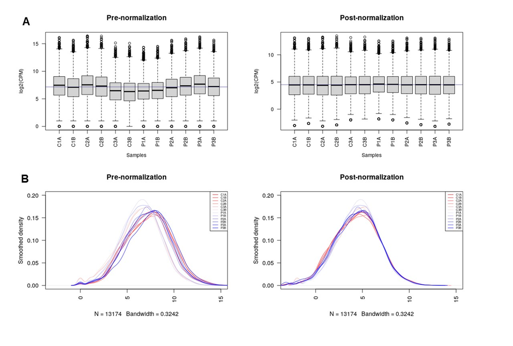

**Figure 1**: Effect of Normalization. (**A**) Boxplots of data before and after normalization. Blue line indicates median of full dataset. (**B**) Smoothed probability density before and after normalization. X-axis is log2(CPM). Plots in this figure can be generated using the code blocks above.

```r
normalized <- calcNormFactors(dispDGE)
normed_cpm <- cpm(normalized)
# if desired, the plots in figure 1 can be generated by un-commenting this code
# box(log2(normed_cpm), "Post-normalization")
# dens(log2(normed_cpm), "Post-normalization")
```

Check for outliers using a histogram. The original authors did not remove any values from the dataset, so it is expected that there are no outliers that would markedly impact data quality. Indeed, there are essentially no outliers on a log2(CPM) scale.

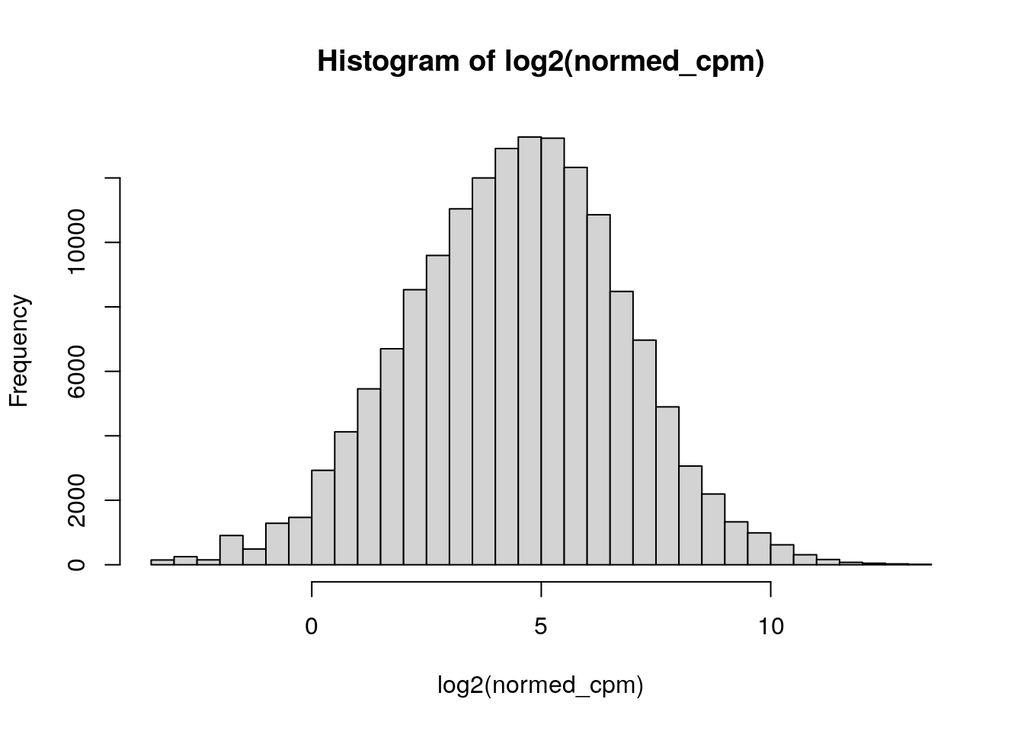

```r
hist(log2(normed_cpm), breaks=50)
```

The biological coefficient of variation (BCV) was also examined after normalization. While several individual genes possessed a high BCV value, the most expressed genes actually had lower-than-average variation (Figure 2A).

```r
dispNormed <- estimateDisp(DGEList(normed_cpm))

# un-comment and run to generate figure 2A
# plotBCV(dispNormed)
```

The mean-variance relationship becomes more clear with a mean-variance plot, highlighting that a negative binomial model fits the dataset better than a Poisson distribution (Figure 2B). Surprisingly, low mean expression levels are not associated with a wide spread of variances, possibly as a result of the stringent filter used.

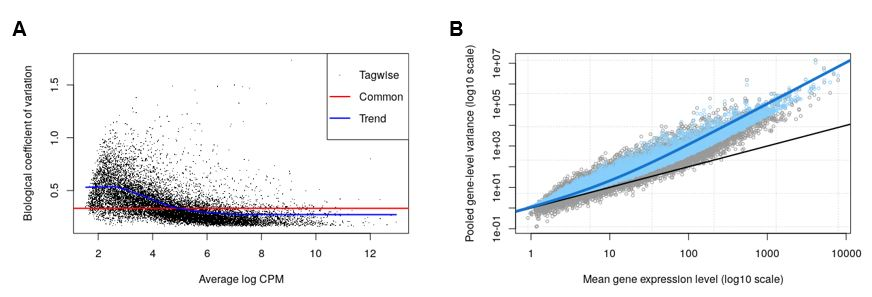

**Figure 2**: Mean-Variance Relationship. (**A**) Biological Coefficient of Variation. (**B**) Mean-Variance plot. Gray markers are raw variances and blue markers are tagwise variances.Fitted blue line represents negative binomial model and black line represents Poisson model. Plots may be generated using the code above.

```r
# un-comment and run to generate figure 2B
# plotMeanVar(dispNormed, show.raw.vars = TRUE, show.tagwise.vars = TRUE,
#            show.ave.raw.vars = FALSE, NBline = TRUE,
#            show.binned.common.disp.vars = FALSE)
```

Finally, the sample separation can be visualized on a multidimensional scaling (MDS) plot using the limma package<sup>7</sup>. The MDS plot indicates that control and PD samples can be divided into two clusters using a boundary defined as a linear combination of the two leading logFC dimensions. However, there remains substantial separation between samples in the same group, especially for PD samples along dimension 1 (Figure 3). Uncovering the physiological significance of dimension 1 in further analyses could be valuable.

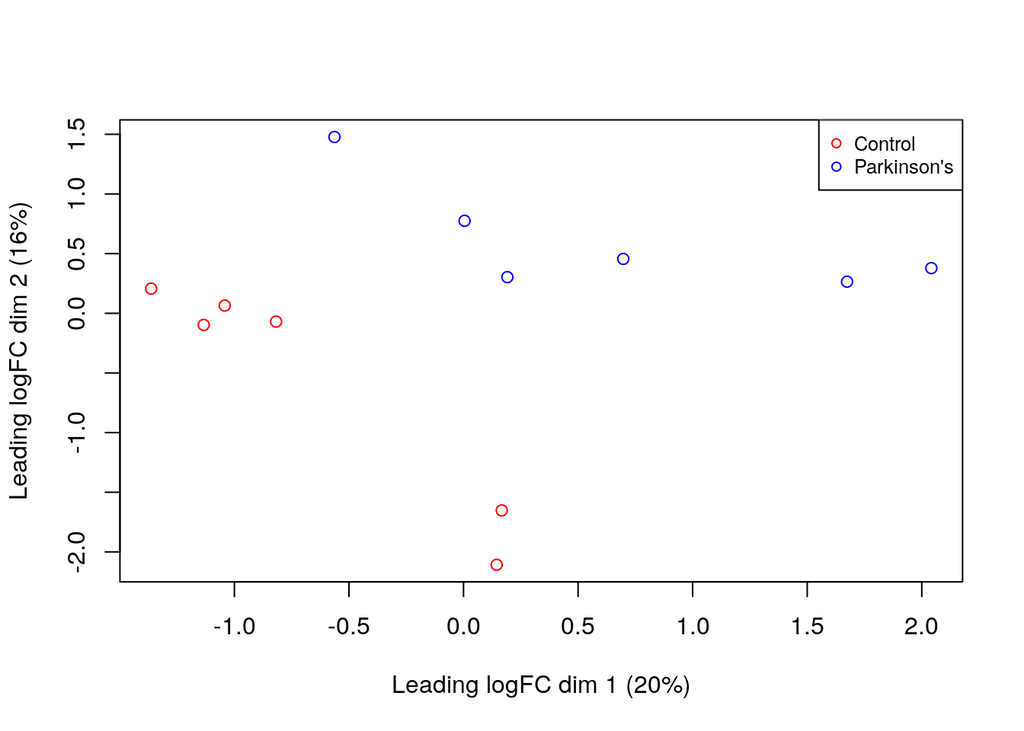

```r
library(limma)
usecolors <- c(rep("red",6), rep("blue", 6))

# un-comment and run to generate figure 3
plotMDS(normalized, pch=1, col=usecolors)
legend("topright", pch=1, legend = c("Control", "Parkinson's"), col=usecolors[6:7], cex=0.8)
```

```r
finalData <- data.frame(normed_cpm)
for (i in 1:6){
    mean_of_samp <- rowSums(finalData[,c(1, 2)])
    finalData <- finalData[, -c(1,2)]
    finalData <- cbind(finalData, mean_of_samp)
}
colnames(finalData) <- c("C1", "C2", "C3", "P1", "P2", "P3")

# calculate coverage as proportion of rows that made it into the final dataset
(dim(finalData)[1])/(dim(rawdata)[1])
```

```
## [1] 0.4974136
```

Final coverage of the processed dataset is 49.7%.

## Links to Assignment Questions

Answers to questions relating to the dataset can be found here

Answers to questions relating to mapping can be found in this section

Answers to questions relating to normalization, outliers, replicates and coverage are presented in this section

## References

1.

Zaccaria, A. *et al.* Multiomic analyses of dopaminergic neurons isolated from human substantia nigra in parkinson’s disease: A descriptive and exploratory study. *Cellular and molecular neurobiology* 1–14 (2022).

2.

Davis, S. & Meltzer, P. S. GEOquery: A bridge between the gene expression omnibus (GEO) and BioConductor. *Bioinformatics* **23**, 1846–1847 (2007).

3.

Durinck, S., Spellman, P. T., Birney, E. & Huber, W. Mapping identifiers for the integration of genomic datasets with the r/bioconductor package biomaRt. *Nature protocols* **4**, 1184–1191 (2009).

4.

Seal, R. L. *et al.* Genenames. Org: The HGNC resources in 2023. *Nucleic Acids Research* **51**, D1003–D1009 (2023).

5.

Robinson, M. D., McCarthy, D. J. & Smyth, G. K. edgeR: A bioconductor package for differential expression analysis of digital gene expression data. *bioinformatics* **26**, 139–140 (2010).

6.

Evans, C., Hardin, J. & Stoebel, D. M. Selecting between-sample RNA-seq normalization methods from the perspective of their assumptions. *Briefings in bioinformatics* **19**, 776–792 (2018).

7.

Ritchie, M. E. *et al.* Limma powers differential expression analyses for RNA-sequencing and microarray studies. *Nucleic acids research* **43**, e47–e47 (2015).